# Because they are good dogs, Brent.

WeRateDogs is a Twitter account that rates people's dogs with a humorous comment about the dog. These ratings almost always have a denominator of 10. The numerators, though? Almost always greater than 10. Why? Because "they're good dogs Brent". WeRateDogs has over 8.7 million followers (as of June 2020) and has received international media coverage.

The Twitter account’s popularity if founded in its humor, and its unique combination of cute animal content and sometimes strict, sometimes loose definition of who or what counts as a dog (see screenshot below).

[figure not shown]

Chelsea, the dog in the tweet above, received an impressive rating of 13 out of 10. The tweet has been retweeted 15.2k times, and liked 132.7k times. Based on these variables, and some other features such as dog breed and "Is it a dog?", @dog_rates offers a fun challenge to create meaningful insights based on their Twitter archive. The following insights are generated from a dataset containing information on WeRateDogs tweets from November 11th 2015 to August 1st 2017.

@dog_rates average rating is at a 10.6 out of 10. 75% of all ratings are at 10 out of 10 or higher. While Snoop Dogg received a dream rating of 420 out of 10, on average tweets rating something other than dogs perform worse than dog-rating tweets. The non-dog ratings include some very low ratings (0/10 and 1/10), ratings below 10/10 are more common than for dogs. The most common rating for dogs is 12/10, for non-dogs it is 10/10. The average dog tweet rating is at 10.9 out of 10, the average non-dog tweet only at 9.5 out of 10.

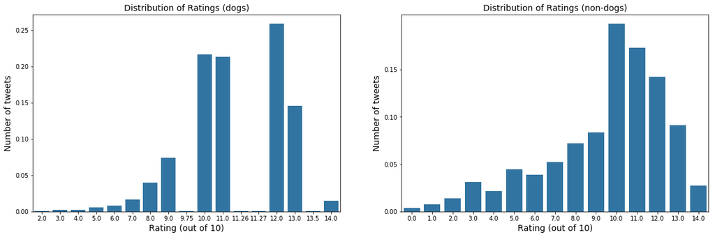

Over time, the average ratings became better and better. From a 10/10 average in the beginning of 2016, it increased to an 12.8/10 average rating in July 2017.

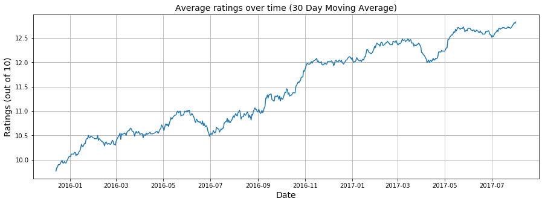

Like Chelsea, the dog breed that is most tweeted about by @dog_rates is Golden Retrievers. Other regularly-rated dogs are Pembrokes, Pugs, Labrador Retrievers, and Samoyeds. Golden Retrievers also win most retweeted dog ratings and most favorited dog ratings. Here they are followed by Pembrokes, Labrador Retrievers, French Bulldogs, and Samoyeds.

While Golden Retrievers dominate in counts, other breeds shine when it comes to highest individual retweet count and favorite count, and highest average breed rating. The latter is ruled by a cute Gordon Setter, the throne for the highest retweet and favorite count goes to Jamesy and his French Bulldog friend:

[figure not shown]

Higher ratings do not automatically lead to more favorites or retweets - the rating numerator is not correlated to the favorite count or retweet count.

As in Jamesy's case, retweet count and favorite count have a strong positive correlation:

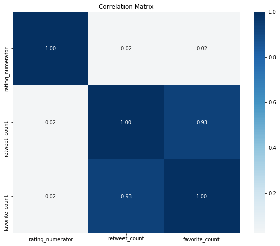